# 3. 决策树在Sklearn中的实现--2

决策树（Decision Tree）是一种非参数的有监督学习方法，它能够从一系列有特征和标签的数据中总结出决策规 则，并用树状图的结构来呈现这些规则，以解决分类和回归问题。决策树算法容易理解，适用各种数据，在解决各 种问题时都有良好表现，尤其是以树模型为核心的各种集成算法，在各个行业和领域都有广泛的应用。

```python
sklearn中的决策树
模块sklearn.tree 包含五个类

tree.DecisionTreeClassifier	分类树
tree.DecisionTreeRegressor	回归树
tree.export_graphviz	将生成的决策树导出为DOT格式，画图用 #pip install graphviz
tree.ExtraTreeClassifier	高随机版本的分类树
tree.ExtraTreeRegressor	高随机版本的回归树
```

### 1.分类树的sklearn快速实现--示例

实现过程在jupyter开发环境中，数据集来自sklearn.datasets

```python
from sklearn import tree
from sklearn.datasets import load_iris #鸢尾花数据集 #load_wine 红酒数据集 #load_cancer
from sklearn.model_selection import train_test_split

iris = load_iris()#数据集中的所有数据
#iris.data #数据集中的数据部分
#iris.target #数据集的标签
#iris.data.shape #数据有几行几列组成
#iris.feature_names #特征名
#iris.target_names #标签名
```

```python
#将数据与标签组合为一张表进行对应
import pandas as pd
df=pd.concat([pd.DataFrame(iris.data,columns=['sepal_L', 'sepal_W', 'petal_L', 'petal_W']),
              pd.DataFrame(iris.target,columns=['label'])], axis=1)
df.to_csv("iris_yyb.csv",index=False)
df.head()
```

|  | sepal_L | sepal_W | petal_L | petal_W | label |
| --- | --- | --- | --- | --- | --- |
| 0 | 5.1 | 3.5 | 1.4 | 0.2 | 0 |
| 1 | 4.9 | 3.0 | 1.4 | 0.2 | 0 |
| 2 | 4.7 | 3.2 | 1.3 | 0.2 | 0 |
| 3 | 4.6 | 3.1 | 1.5 | 0.2 | 0 |
| 4 | 5.0 | 3.6 | 1.4 | 0.2 | 0 |

```python
#将数据集分为训练集与测试集(二维矩阵)
x_train, x_test, y_train, y_test = train_test_split(iris.data, iris.target, test_size=0.3)
#print(Xtest,Ytest)
```

```python
#criterion参数正是用来决定不纯度计算方法的（默认使用gini）
#输入**“entropy”**，使用信息熵
#输入**“gini”**，使用基尼系数

#建模
clf = tree.DecisionTreeClassifier(criterion="gini"#"entropy"
                                  ,random_state=20 #用来设置分枝中的随机数量(默认为None)
                                  ,splitter="random" #用来控制决策树中的随机选项(best,random)
                                 )
clf = clf.fit(x_train, y_train) #训练
score = clf.score(x_test, y_test)#测试集上准确率---得分

score
```

```
0.9555555555555556
```

```python
#画树
#feature_name = ['sepal length', 'sepal width', 'petal length', 'petal width']
#class_name = ['setosa', 'versicolor', 'virginica']
import graphviz
dot_data = tree.export_graphviz(clf
                                ,feature_names = list(iris.feature_names)
                                ,class_names = list(iris.target_names)
                                ,filled=True #进行颜色填充
                                ,rounded=True #将树中方形改为圆形
                                ,max_depth=13
                                )
graph = graphviz.Source(dot_data) #从dot_data中获取生成树的代码并赋值给graph
graph #输出树
```

[figure not shown]

```
[Text(0.36363636363636365, 0.9444444444444444, 'X[3] <= 1.295\ngini = 0.665\nsamples = 105\nvalue = [34, 33, 38]'),
```

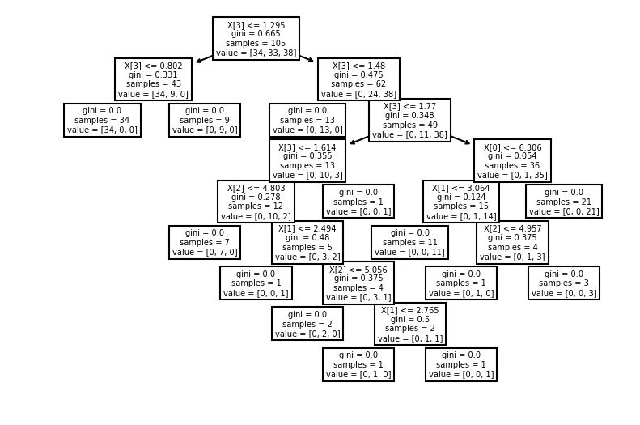

```python
import matplotlib.pyplot as plt
plt.figure(figsize=(6, 4), dpi=150)
tree.plot_tree(clf)
```

```python
#特征重要性
clf.feature_importances_
##通过zip将特征名与特征重要性结合
[*zip(iris.feature_names, clf.feature_importances_)]
```

[output not shown]

```python
"""
sklearn.tree.export_graphviz(decision_tree, out_file=None, *, max_depth=None, feature_names=None,
class_names=None, label='all', filled=False, leaves_parallel=False, impurity=True, node_ids=False,
proportion=False, rotate=False, rounded=False, special_characters=False, precision=3, fontname='helvetica')
"""
此函数生成决策树的 GraphViz 表示，然后将其写入 out_file 。以 DOT 格式导出决策树。
参数：
decision_tree：决策树分类器,要导出到 GraphViz 的决策树。
out_file：对象或字符串，默认=无,输出文件的句柄或名称。如果 None ，则结果以字符串形式返回。
max_depth：整数，默认=无,表示的最大深度。如果没有，则完全生成树。
feature_names：str列表，默认=无. 如果 None 将使用通用名称(“feature_0”、“feature_1”、...)。
class_names：str 或 bool 的列表，默认 = 无
每个目标类别的名称按数字升序排列。仅与分类相关，不支持multi-output。如果 True ，则显示类名的符号表示。
label：{‘all’, ‘root’, ‘none’}，默认='全部'
是否显示杂质标签等。选项包括‘all’ 显示在每个节点，‘root’ 仅显示在顶部根节点，或‘none’ 不显示在任何节点。
filled：布尔，默认=假
当设置为 True 时，绘制节点以指示分类的多数类、回归值的极值或 multi-output 的节点纯度。
leaves_parallel：布尔，默认=假,当设置为 True 时，在树的底部绘制所有叶节点。
impurity：布尔，默认=真,当设置为 True 时，显示每个节点的杂质。

node_ids：布尔，默认=假
当设置为 True 时，在每个节点上显示 ID 号。

proportion：布尔，默认=假
当设置为 True 时，将 ‘values’ 和/或 ‘samples’ 的显示分别更改为比例和百分比。

rotate：布尔，默认=假
当设置为 True 时，将树从左到右而不是自上而下。

rounded：布尔，默认=假
当设置为 True 时，绘制圆角节点框。

special_characters：布尔，默认=假
当设置为 False 时，忽略特殊字符以兼容 PostScript。

precision：整数，默认=3
每个节点的杂质、阈值和值属性值中浮点精度的位数。

fontname：str，默认='helvetica',用于呈现文本的字体名称。

返回：
dot_data：str
GraphViz 点格式的输入树的字符串表示形式。仅在 out_file 为 None 时返回。
```

剪枝参数 为了使决策树有更好的泛化性，我们要对决策树进行剪枝，剪枝策略对决策树的影响巨大，正确的剪枝策略是优化决策树的算法核心 max_depth：限制树的最大深度，超过设定深度的树枝全部剪掉 min_samples_leaf & min_samples_split：min_samples_leaf 限定一个节点在分枝后每个子节点都必须包含至少min_samples_leaf个训练样本，否则分枝不会产生(一般从=5开始使用)； min_samples_split 限定一个节点必须要包含至少min_samples_split个训练样本，这个节点才被允许分枝 max_features & min_impurity_decrease：max_features与max_depth用法相同；min_impurity_decrease 限制信息增益的大小，信息增益小于设定数值的分枝不会发生

重要属性和接口 对决策树来说最重要的是feature*importances*，能够查看各个特征对模型的重要性。 sklearn中许多算法的接口都是相似的，比如fit、score，几乎对每个算法都适用。决策树常用的接口还有apply、predict。 apply：输入测试集返回每个测试样本所在的叶子节点的索引 predict：输入测试集返回每个测试样本的标签

```python
#print(clf.predict(x_test))

print(clf.predict(x_test) - y_test)
```

```
[ 0  0  0  0  0  0  0  0  0  0  0  0  0  0  0  0  0  0  0  0  0  0  0  0
  0 -1  0  0  0  0  0  0  0  0  0  1  0  0  0  0  0  0  0  0  0]
```

```python
#score()
y_predict=clf.predict(x_test)
sum(y_test == y_predict) / len(y_predict)
```

[output not shown]

注：所有接口中要求输入x_train和x_test的部分，输入的特征矩阵必须是一个二维矩阵。sklearn不接受任何一维矩阵作为特征矩阵被输入。若数据只有一个特征，必须用reshape(-1,1)来给矩阵增维；若数据只有一个特征和一个样本，使用reshape(1,-1)来给矩阵增维。

```python
clf.predict(x_test[0].reshape(1,-1))==[y_test[0]]
```

```
array([ True])
```

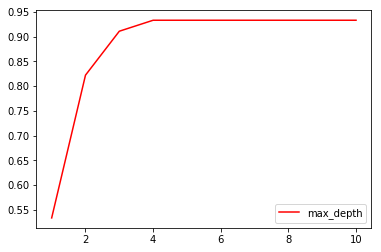

```python
#画出超参数学习曲线确定最优剪枝参数
import matplotlib.pyplot as plt
test = []
for i in range(10):
    clf = tree.DecisionTreeClassifier(max_depth=i+1
                                     ,criterion="entropy"
                                     ,random_state=30
                                     ,splitter="random"
                                     )
    clf = clf.fit(x_train, y_train)
    score = clf.score(x_test, y_test)
    test.append(score)
plt.plot(range(1,11),test,color="red",label="max_depth")
plt.legend()
plt.show()
```

### 2.CART回归树的sklearn快速实现--示例

```python
# 科学计算模块
import numpy as np
import pandas as pd

# 绘图模块
import matplotlib.pyplot as plt

# 自定义模块
#from yyb_basic_function import *

# Scikit-Learn相关模块
# 评估器类
from sklearn.preprocessing import StandardScaler
from sklearn.preprocessing import PolynomialFeatures
from sklearn.linear_model import LogisticRegression
from sklearn.pipeline import make_pipeline
from sklearn.model_selection import GridSearchCV
from sklearn import tree
from sklearn.tree import DecisionTreeClassifier,DecisionTreeRegressor

# 实用函数
from sklearn.model_selection import train_test_split
from sklearn.metrics import accuracy_score

# 数据准备
from sklearn.datasets import load_iris
```

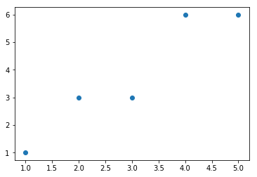

```python
#数据--1 demo
#创建一个简单的回归数据集如下，该数据集只包含一个特征和一个连续型标签
data = np.array([[1, 1], [2, 3], [3, 3], [4, 6], [5, 6]])
plt.scatter(data[:, 0], data[:, 1])
```

```
[6. 6. 6. 3.]
```

```
[Text(0.6, 0.8333333333333334, 'X[0] <= 3.5\nsquared_error = 3.76\nsamples = 5\nvalue = 3.8'),
```

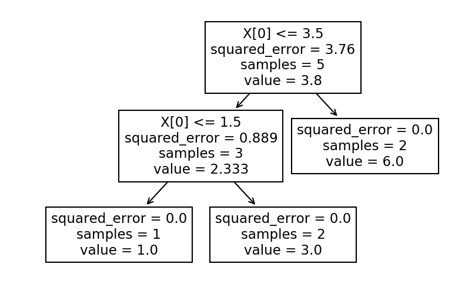

```python
from sklearn.tree import DecisionTreeRegressor
clf = DecisionTreeRegressor()#建模
clf=clf.fit(data[:, 0].reshape(-1, 1), data[:, 1])#训练

Y = clf.predict([[4.5],[5.3],[6.4],[2.7]])#预测
print(Y)

# 同样可以借助tree.plot_tree进行结果的可视化CART回归树
plt.figure(figsize=(6, 4), dpi=150)
tree.plot_tree(clf)
```

```python
import graphviz
dot_data = tree.export_graphviz(clf
                                ,feature_names = ['X']
                                #,class_names = ['Y']
                                ,filled=True #进行颜色填充
                                ,rounded=True #将树中方形改为圆形
                                ,max_depth=2
                                )
graph = graphviz.Source(dot_data) #从dot_data中获取生成树的代码并赋值给graph
graph #输出树
```

[figure not shown]

```python
分析如下：
```

#### 生成备选规则

回归树中寻找切分点的方式和分类树的方式相同，都是逐特征寻找不同取值的中间点作为切分点。对于上述数据集来说，由于只有一个特征，并且总共有5个不同的取值，因此切分点有4个。而根据此前介绍，有几个切分点就有几种数据集划分方式、即有同等数量的备选划分规则、或有同等数量的树的生长方式。初始数据集的4个不同的划分方式，可以通过如下方式进行呈现：

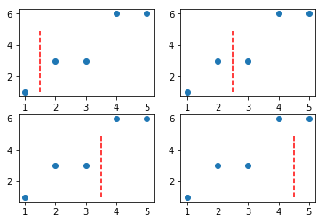

```python
y_range = np.arange(1, 5, 0.1)

plt.subplot(221)
plt.scatter(data[:, 0], data[:, 1])
plt.plot(np.full_like(y_range, 1.5), y_range, 'r--')
plt.subplot(222)
plt.scatter(data[:, 0], data[:, 1])
plt.plot(np.full_like(y_range, 2.5), y_range, 'r--')
plt.subplot(223)
plt.scatter(data[:, 0], data[:, 1])
plt.plot(np.full_like(y_range, 3.5), y_range, 'r--')
plt.subplot(224)
plt.scatter(data[:, 0], data[:, 1])
plt.plot(np.full_like(y_range, 4.5), y_range, 'r--')
```

#### 挑选规则

根据某种评估标准来寻找最佳划分方式。回归树的该步骤和分类树差异较大，分类树中我们是采用基尼系数或者信息熵来衡量划分后数据集标签不纯度下降情况来挑选最佳划分方式，而在回归树中，则是根据划分之后子数据集MSE下降情况来进行最佳划分方式的挑选。子数据集整体的MSE计算方法是先计算每个子集单独的MSE，然后再通过加权求和的方法来进行计算两个子集整体的MSE。

要计算MSE，就必须给出一个预测值，才能根据预测值和真实值计算MSE。而CART回归树在进行子数据集的划分之后，会针对每个子数据集给出一个预测值（注意是针对一个子数据集中所有数据给出一个预测值，而不是针对每一个数给出一个预测值），而该预测值会依照让对应子数据集MSE最小的目标进行计算得出。

选取这组数的质心能够让组内误差平方和计算结果最小。一维数据的质心，其实就是这组数据的均值。那么也就是说，在围绕让每一个子数据集MSE取值最小这一目标下，每个子数据集的最佳预测值就是这个子数据集真实标签的均值。

具体计算过程如下，例如对上述第一种划分数据集的情况来说，每个子数据集的预测值和MSE计算结果如下：

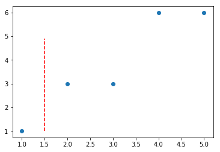

```python
plt.scatter(data[:, 0], data[:, 1])
plt.plot(np.full_like(y_range, 1.5), y_range, 'r--')
```

对应划分如下图表示：

[figure not shown]

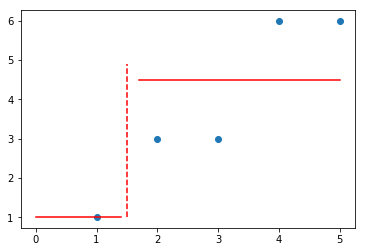

```python
### 此时计算子数据集B1和B2的MSE，首先是两个数据集的预测值，也就是均值：
data[0, 1] #1
# B1数据集的预测值
y_1 = np.mean(data[0, 0]) #1.0

data[1: , 1] #array([3, 3, 6, 6])
# B2数据集的预测值
y_2 = np.mean(data[1: , 1]) #4.5

# 模型预测结果
plt.scatter(data[:, 0], data[:, 1])
plt.plot(np.full_like(y_range, 1.5), y_range, 'r--')
plt.plot(np.arange(0, 1.5, 0.1), np.full_like(np.arange(0, 1.5, 0.1), y_1), 'r-')
plt.plot(np.arange(1.7, 5.1, 0.1), np.full_like(np.arange(1.7, 5.1, 0.1), y_2), 'r-')
```

```python
### 然后计算两个子集的MSE：
# B1的MSE
mse_b1 = 0
# B2的MSE
mse_b2 = np.power(data[1:,1]-4.5,2).sum()/4  #2.25
### 然后和CART分类树一样，以各子集所占全集的样本比例为权重，通过加权求和的方式计算
###两个子集整体的MSE：
mse_b = 1/5 * mse_b1 + 4/5 * mse_b2  #1.8
```

```python
###而父节点的MSE为：
data[:,1].mean() #3.8
mse_a = np.power(data[:,1]-data[:,1].mean(),2).sum()/data[:,1].size
#3.7599999999999993
###因此，本次划分所降低的MSE为：
mse_a - mse_b  #1.9599999999999993
###即为该种划分方式的最终评分。

###同理可以计算出余下三种划分的最终评分。然后从中挑选能够最大程度降低MSE的划分方式。
```

```
1.9599999999999993
```

```
[1.9599999999999993, 2.1599999999999993, 3.226666666666666, 1.209999999999999]
```

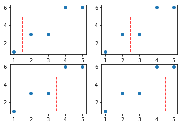

```python
impurity_decrease = []

for i in range(4):
    # 寻找切分点
    splitting_point = data[i: i+2 , 0].mean()
    # 进行数据集切分
    data_b1 = data[data[:, 0] <= splitting_point]
    data_b2 = data[data[:, 0] > splitting_point]
    # 分别计算两个子数据集的MSE
    mse_b1 = np.power(data_b1[:,1] - data_b1[:,1].mean(),2).sum() / data_b1[:,1].size
    mse_b2 = np.power(data_b2[:,1] - data_b2[:,1].mean(),2).sum() / data_b2[:,1].size
    # 计算两个子数据集整体的MSE
    mse_b = data_b1[: , 1].size/data[: , 1].size * mse_b1 + data_b2[: , 1].size/data[: , 1].size * mse_b2
    #mse_b = mse_b1 + mse_b2

    # 计算当前划分情况下MSE下降结果
    impurity_decrease.append(mse_a - mse_b)
print(impurity_decrease)
#[1.9599999999999993, 2.1599999999999993, 3.226666666666666, 1.209999999999999]

plt.subplot(221)
plt.scatter(data[:, 0], data[:, 1])
plt.plot(np.full_like(y_range, 1.5), y_range, 'r--')
plt.subplot(222)
plt.scatter(data[:, 0], data[:, 1])
plt.plot(np.full_like(y_range, 2.5), y_range, 'r--')
plt.subplot(223)
plt.scatter(data[:, 0], data[:, 1])
plt.plot(np.full_like(y_range, 3.5), y_range, 'r--')
plt.subplot(224)
plt.scatter(data[:, 0], data[:, 1])
plt.plot(np.full_like(y_range, 4.5), y_range, 'r--')
```

#### 结果看出，第三种划分情况能够最大程度降低MSE，即此时树模型的第一次生长情况如下：

[figure not shown]

#### 进行多轮迭代

当然，和CART分类树一样，接下来，我们就能够进一步围绕B1和B2进行进一步划分。此时B2的MSE已经为0，因此无需再进行划分，而B1的MSE为0.88，还可以进一步进行划分。当然B1的划分过程也和A数据集的划分过程一致，寻找能够令子集MSE下降最多的方式进行切分。不过由于B1数据集本身较为简单，通过观察不难发现，我们可以以x<= 1.5作为划分条件对其进行切分，进一步切分出来的子集的MSE都将取值为0。

[figure not shown]

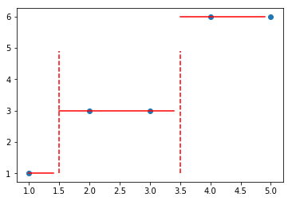

```python
### 观察当回归树生长了两层之后，相关规则对原始数据集的划分情况：
# 数据分布
plt.scatter(data[:, 0], data[:, 1])
# 两次划分
plt.plot(np.full_like(y_range, 3.5), y_range, 'r--')
plt.plot(np.full_like(y_range, 1.5), y_range, 'r--')
# 预测结果
plt.plot(np.arange(1, 1.5, 0.1), np.full_like(np.arange(1, 1.5, 0.1), 1), 'r-')
plt.plot(np.arange(1.5, 3.5, 0.1), np.full_like(np.arange(1.5, 3.5, 0.1), 3), 'r-')
plt.plot(np.arange(3.5, 5, 0.1), np.full_like(np.arange(3.5, 5, 0.1), 6), 'r-')
```

不难发现，回归树的对标签的预测，实际上是一种“分区定值”的预测，建模过程的实际表现是对样本进行划分、然后每个区间给定一个预测值，并且树的深度越深、对样本空间的划分次数就越多、样本空间就会被分割成更多的子空间。

### 3. Sklearn中Adaboost模型

class sklearn.ensemble.AdaBoostClassifier(base_estimator=None, n_estimators=50, learning_rate=1.0, algorithm='SAMME.R', random_state=None) base_estimator:基分类器，默认是决策树，在该分类器基础上进行boosting，理论上可以是任意一个分类器，但是如果是其他分类器时需要指明样本权重。 n_estimators:基分类器提升（循环）次数，默认是50次，这个值过大，模型容易过拟合；值过小，模型容易欠拟合。 learning_rate:学习率，表示梯度收敛速度，默认为1，如果过大，容易错过最优值，如果过小，则收敛速度会很慢；该值需要和n_estimators进行一个权衡，当分类器迭代次数较少时，学习率可以小一些，当迭代次数较多时，学习率可以适当放大。 algorithm:boosting算法，也就是模型提升准则，有两种方式SAMME, 和SAMME.R两种，默认是SAMME.R，两者的区别主要是弱学习器权重的度量，前者是对样本集预测错误的概率进行划分的，后者是对样本集的预测错误的比例，即错分率进行划分的，默认是用的SAMME.R。 random_state:随机种子设置。

关于Adaboost模型本身的参数并不多，但是我们在实际中除了调整Adaboost模型参数外，还可以调整基分类器的参数，关于基分类的调参，和单模型的调参是完全一样的，比如默认的基分类器是决策树，那么这个分类器的调参和我们之前的Sklearn参数详解——决策树是完全一致。 Adaboost-对象先生成一个分类器

```python
from sklearn.datasets import load_iris
from sklearn.ensemble import AdaBoostClassifier
iris=load_iris()
#Adaboost-对象先生成一个分类器
model=AdaBoostClassifier(n_estimators=100)
clf=model.fit(iris.data,iris.target)
```

```python
clf.estimators_ #以列表的形式返回所有的分类器。
```

```python
clf.classes_ #类别标签
```

```python
clf.estimator_weights_  #每个分类器权重。
```

```python
clf.estimator_errors_ #每个分类器的错分率，与分类器权重相对应。
```

```python
clf.feature_importances_ #特征重要性，这个参数使用前提是基分类器也支持这个属性。
```

```
array([0.  , 0.  , 0.54, 0.46])
```

Adaboost-方法 decision_function(X):返回决策函数值（比如svm中的决策距离） fit(X,Y):在数据集（X,Y）上训练模型。 get_parms():获取模型参数 predict(X):预测数据集X的结果。 predict_log_proba(X):预测数据集X的对数概率。 predict_proba(X):预测数据集X的概率值。 score(X,Y):输出数据集（X,Y）在模型上的准确率。 staged_decision_function(X):返回每个基分类器的决策函数值 staged_predict(X):返回每个基分类器的预测数据集X的结果。 staged_predict_proba(X):返回每个基分类器的预测数据集X的概率结果。 staged_score(X, Y):返回每个基分类器的预测准确率。

直接运行staged方法，不会直接输出结果，而是输出一个生成器，要想得到具体的结果，需要遍历打印输出。clf.staged_score(iris.data, iris.target)

```python
n=0
for s in clf.staged_score(iris.data, iris.target):
    print(s)
    n=n+1
print("总输出项：{}".format(n))
```

[output not shown]

### 4. Sklearn中GBDT模型

GBDT和Adaboost都是Boosting模型的一种，但是略有不同，主要有以下两点不同： GBDT使用的基模型是CART决策树，且只能是CART决策树，而Adaboost的默认基模型是CART决策树，可以是其他模型。 GBDT通过计算每次模型的负梯度来进行模型迭代，而Adaboost模型则根据错分率来进行模型迭代。

```python
class sklearn.ensemble.GradientBoostingClassifier(loss='deviance', learning_rate=0.1, n_estimators=100, subsample=1.0, criterion='friedman_mse', min_samples_split=2, min_samples_leaf=1, min_weight_fraction_leaf=0.0, max_depth=3, min_impurity_decrease=0.0, min_impurity_split=None, init=None, random_state=None, max_features=None, verbose=0, max_leaf_nodes=None, warm_start=False, presort='auto')
因基分类器是决策树，所以很多参数都是用来控制决策树生成的，这些参数与前面决策树参数基本一致，对于一致的就不进行赘述。关于决策树参数看这里：Sklearn参数详解--决策树

loss:损失函数度量，有对数似然损失deviance和指数损失函数exponential两种，默认是deviance，即对数似然损失，如果使用指数损失函数，则相当于Adaboost模型。

criterion: 样本集的切分策略，决策树中也有这个参数，但是两个参数值不一样，这里的参数值主要有friedman_mse、mse和mae3个，分别对应friedman最小平方误差、最小平方误差和平均绝对值误差，friedman最小平方误差是最小平方误差的近似。

subsample:采样比例，这里的采样和bagging的采样不是一个概念，这里的采样是指选取多少比例的数据集利用决策树基模型去boosting，默认是1.0，即在全量数据集上利用决策树去boosting。

warm_start:“暖启动”，默认值是False，即关闭状态，如果打开则表示，使用先前调试好的模型，在该模型的基础上继续boosting，如果关闭，则表示在样本集上从新训练一个新的基模型，且在该模型的基础上进行boosting。

属性/对象
feature_importance_:特征重要性。
oob_improvement_:每一次迭代对应的loss提升量。oob_improvement_[0]表示第一次提升对应的loss提升量。
train_score_:表示在样本集上每次迭代以后的对应的损失函数值。
loss_:损失函数。
estimators_：基分类器个数。

方法
apply(X)：将训练好的模型应用在数据集X上，并返回数据集X对应的叶指数。
decision_function(X):返回决策函数值（比如svm中的决策距离）
fit(X,Y):在数据集（X,Y）上训练模型。
get_parms():获取模型参数
predict(X):预测数据集X的结果。
predict_log_proba(X):预测数据集X的对数概率。
predict_proba(X):预测数据集X的概率值。
score(X,Y):输出数据集（X,Y）在模型上的准确率。
staged_decision_function(X):返回每个基分类器的决策函数值
staged_predict(X):返回每个基分类器的预测数据集X的结果。
staged_predict_proba(X):返回每个基分类器的预测数据集X的概率结果。
```

### 5.随机森林的sklearn快速实现--示例

```python
class sklearn.ensemble.RandomForestClassifier（
    n_estimators=10, criterion='gini', max_depth=None,
    min_samples_split=2, min_samples_leaf=1, min_weight_fraction_leaf=0.0,
    max_features='auto', max_leaf_nodes=None, min_impurity_decrease=0.0,
    min_impurity_split=None, bootstrap=True, oob_score=False, n_jobs=1,
    random_state=None, verbose=0, warm_start=False, class_weight=None)
因随机森林中的树是决策树，所以关于决策树的大部分参数与前面决策树模型中的参数意思一致，这里就不再赘述，可查看：Sklearn参数详解--决策树
n_estimators:随机森林中树的棵树，默认是10棵。
criterion:样本集切分策略，默认是gini指数，此时树模型为CART模型，当值选为信息增益的时候，模型就成了ID3模型，默认为CART模型。
bootstrap:是统计学中的一种重采样技术，可以简单理解成是有放回地抽样，默认是True,即采取有放回抽样这种策略，这不就是bagging的思想么。
oob_score:袋外估计(out-of-bag)，这个外是针对于bagging这个袋子而言的，我们知道，bagging采取的随机抽样的方式去建立树模型，那么那些未被抽取到的样本集，也就是未参与建立树模型的数据集就是袋外数据集，我们就可以用这部分数据集去验证模型效果，默认值为False。

对象/属性
estimators_：打印输出随机森林中所有的树。
classes_：输出样本集的类别。
n_classes_：输出类别数量。
n_features_：特征数量。
n_outputs_：当模型被fit时的输出维度。看看下图来感受一些这个属性。
feature_importances_：特征重要性。
oob_score_：袋外估计准确率得分，必须是oob_score参数选择True的时候才可用。
oob_decision_function_：袋外估计对应的决策函数。
方法
apply(X)：将训练好的模型应用在数据集X上，并返回数据集X对应的叶指数。
decision_function(X):返回决策函数值（比如svm中的决策距离）
fit(X,Y):在数据集（X,Y）上训练模型。
get_parms():获取模型参数
predict(X):预测数据集X的结果。
predict_log_proba(X):预测数据集X的对数概率。
predict_proba(X):预测数据集X的概率值。
score(X,Y):输出数据集（X,Y）在模型上的准确率。
```

[output not shown]